# 1. Importing Libraries

```python
import numpy as np
import pandas as pd
import seaborn as sns
import matplotlib.pyplot as plt
import sklearn
from sklearn.model_selection import train_test_split
from sklearn.preprocessing import StandardScaler
from sklearn.linear_model import LogisticRegression
from sklearn.metrics import accuracy_score,confusion_matrix
from sklearn.preprocessing import LabelEncoder
import warnings
warnings.filterwarnings('ignore')

from sklearn.neighbors import KNeighborsClassifier
from sklearn.naive_bayes import GaussianNB
from sklearn.ensemble import RandomForestClassifier
from sklearn.ensemble import StackingClassifier
from sklearn.ensemble import AdaBoostClassifier, GradientBoostingClassifier
from sklearn.tree import DecisionTreeClassifier
```

# 2. Load the dataset and display a sample of five rows of the data frame.

```python
from google.colab import drive
drive.mount('/content/drive')
```

```python
df = pd.read_csv('/content/drive/MyDrive/heart_2020_cleaned.csv')
df.head()
```

|  | HeartDisease | BMI | Smoking | AlcoholDrinking | Stroke | PhysicalHealth | MentalHealth | DiffWalking | Sex | AgeCategory | Race | Diabetic | PhysicalActivity | GenHealth | SleepTime | Asthma | KidneyDisease | SkinCancer |
| --- | --- | --- | --- | --- | --- | --- | --- | --- | --- | --- | --- | --- | --- | --- | --- | --- | --- | --- |
| 0 | No | 16.60 | Yes | No | No | 3.0 | 30.0 | No | Female | 55-59 | White | Yes | Yes | Very good | 5.0 | Yes | No | Yes |
| 1 | No | 20.34 | No | No | Yes | 0.0 | 0.0 | No | Female | 80 or older | White | No | Yes | Very good | 7.0 | No | No | No |
| 2 | No | 26.58 | Yes | No | No | 20.0 | 30.0 | No | Male | 65-69 | White | Yes | Yes | Fair | 8.0 | Yes | No | No |
| 3 | No | 24.21 | No | No | No | 0.0 | 0.0 | No | Female | 75-79 | White | No | No | Good | 6.0 | No | No | Yes |
| 4 | No | 23.71 | No | No | No | 28.0 | 0.0 | Yes | Female | 40-44 | White | No | Yes | Very good | 8.0 | No | No | No |

# 3. Check the shape of the data (number of rows and columns). Check the general information about the dataframe using the .info() method.

```python
df.shape
```

```
(319795, 18)
```

```python
df.info()
```

```
<class 'pandas.core.frame.DataFrame'>
RangeIndex: 319795 entries, 0 to 319794
Data columns (total 18 columns):
 #   Column            Non-Null Count   Dtype
---  ------            --------------   -----
 0   HeartDisease      319795 non-null  object
 1   BMI               319795 non-null  float64
 2   Smoking           319795 non-null  object
 3   AlcoholDrinking   319795 non-null  object
 4   Stroke            319795 non-null  object
 5   PhysicalHealth    319795 non-null  float64
 6   MentalHealth      319795 non-null  float64
 7   DiffWalking       319795 non-null  object
 8   Sex               319795 non-null  object
 9   AgeCategory       319795 non-null  object
 10  Race              319795 non-null  object
 11  Diabetic          319795 non-null  object
 12  PhysicalActivity  319795 non-null  object
 13  GenHealth         319795 non-null  object
 14  SleepTime         319795 non-null  float64
 15  Asthma            319795 non-null  object
 16  KidneyDisease     319795 non-null  object
 17  SkinCancer        319795 non-null  object
dtypes: float64(4), object(14)
memory usage: 43.9+ MB
```

# 4. Check the statistical summary of the dataset and write your inferences.

```python
df.describe().T
```

|  | count | mean | std | min | 25% | 50% | 75% | max |
| --- | --- | --- | --- | --- | --- | --- | --- | --- |
| BMI | 319795.0 | 28.325399 | 6.356100 | 12.02 | 24.03 | 27.34 | 31.42 | 94.85 |
| PhysicalHealth | 319795.0 | 3.371710 | 7.950850 | 0.00 | 0.00 | 0.00 | 2.00 | 30.00 |
| MentalHealth | 319795.0 | 3.898366 | 7.955235 | 0.00 | 0.00 | 0.00 | 3.00 | 30.00 |
| SleepTime | 319795.0 | 7.097075 | 1.436007 | 1.00 | 6.00 | 7.00 | 8.00 | 24.00 |

```python
df.describe(include = 'O').T
```

|  | count | unique | top | freq |
| --- | --- | --- | --- | --- |
| HeartDisease | 319795 | 2 | No | 292422 |
| Smoking | 319795 | 2 | No | 187887 |
| AlcoholDrinking | 319795 | 2 | No | 298018 |
| Stroke | 319795 | 2 | No | 307726 |
| DiffWalking | 319795 | 2 | No | 275385 |
| Sex | 319795 | 2 | Female | 167805 |
| AgeCategory | 319795 | 13 | 65-69 | 34151 |
| Race | 319795 | 6 | White | 245212 |
| Diabetic | 319795 | 4 | No | 269653 |
| PhysicalActivity | 319795 | 2 | Yes | 247957 |
| GenHealth | 319795 | 5 | Very good | 113858 |
| Asthma | 319795 | 2 | No | 276923 |
| KidneyDisease | 319795 | 2 | No | 308016 |
| SkinCancer | 319795 | 2 | No | 289976 |

# 5. Check the percentage of missing values in each column of the data frame. Drop the missing values if there are any.

```python
df.isnull().sum()/len(df)*100
```

```
HeartDisease        0.0
BMI                 0.0
Smoking             0.0
AlcoholDrinking     0.0
Stroke              0.0
PhysicalHealth      0.0
MentalHealth        0.0
DiffWalking         0.0
Sex                 0.0
AgeCategory         0.0
Race                0.0
Diabetic            0.0
PhysicalActivity    0.0
GenHealth           0.0
SleepTime           0.0
Asthma              0.0
KidneyDisease       0.0
SkinCancer          0.0
dtype: float64
```

# 6. Check if there are any duplicate rows. If any drop them and check the shape of the dataframe after dropping duplicates.

```python
len(df[df.duplicated()])
```

```
18078
```

```python
df.drop_duplicates(inplace=True)
```

```python
df.shape
```

```
(301717, 18)
```

# 7. Check the distribution of the target variable (i.e. 'HeartDisease') and write your observations.

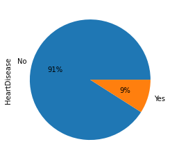

```python
df['HeartDisease'].value_counts().plot(kind='pie',autopct='%1.0f%%')
plt.show()
```

9% of the peoples are having heart disease

# 8. Visualize the distribution of the target column 'Heart disease' with respect to various categorical features and write your observations

```python
categorical_features=df.select_dtypes(include=[np.object])
categorical_features.columns
```

```
Index(['HeartDisease', 'Smoking', 'AlcoholDrinking', 'Stroke', 'DiffWalking',
       'Sex', 'AgeCategory', 'Race', 'Diabetic', 'PhysicalActivity',
       'GenHealth', 'Asthma', 'KidneyDisease', 'SkinCancer'],
      dtype='object')
```

**distribution of the number of people with heart disease from various factors**

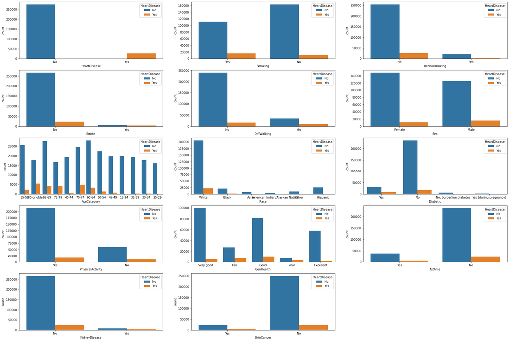

```python
i=1
plt.figure(figsize=(30,25))
for feature in categorical_features:
    plt.subplot(6,3,i)
    sns.countplot(x=feature,hue='HeartDisease',data=df)
    i +=1
```

# 9. Check the unique categories in the column 'Diabetic'. Replace 'Yes (during pregnancy)' as 'Yes' and 'No, borderline diabetes' as 'No'

```python
df['Diabetic'].unique()
```

```
array(['Yes', 'No', 'No, borderline diabetes', 'Yes (during pregnancy)'],
      dtype=object)
```

```python
df['Diabetic']=df['Diabetic'].replace({'Yes (during pregnancy)':'Yes','No, borderline diabetes':'No'})
df['Diabetic'].value_counts()
```

```
No     258572
Yes     43145
Name: Diabetic, dtype: int64
```

# 10. For the target column 'HeartDiease', Replace 'No' as 0 and 'Yes' as 1.

```python
df['HeartDisease']=df['HeartDisease'].replace({'Yes':1,'No':0})
```

```python
df['HeartDisease'].value_counts()
```

```
0    274456
1     27261
Name: HeartDisease, dtype: int64
```

# 11. Label Encode the columns "AgeCategory", "Race", and "GenHealth". Encode the rest of the columns using dummy encoding approach.

```python
object_type_variables=[i for i in df[['AgeCategory','Race','GenHealth']] if df.dtypes[i]==object]
object_type_variables

le =LabelEncoder()

def encoder(df):
    for i in object_type_variables:
        q=le.fit_transform(df[i].astype(str))
        df[i]=q
        df[i]=df[i].astype(int)
encoder(df)
```

```python
df=pd.get_dummies(df,drop_first=True)
df.head(5)
```

|  | HeartDisease | BMI | PhysicalHealth | MentalHealth | AgeCategory | Race | GenHealth | SleepTime | Smoking_Yes | AlcoholDrinking_Yes | Stroke_Yes | DiffWalking_Yes | Sex_Male | Diabetic_Yes | PhysicalActivity_Yes | Asthma_Yes | KidneyDisease_Yes | SkinCancer_Yes |
| --- | --- | --- | --- | --- | --- | --- | --- | --- | --- | --- | --- | --- | --- | --- | --- | --- | --- | --- |
| 0 | 0 | 16.60 | 3.0 | 30.0 | 7 | 5 | 4 | 5.0 | 1 | 0 | 0 | 0 | 0 | 1 | 1 | 1 | 0 | 1 |
| 1 | 0 | 20.34 | 0.0 | 0.0 | 12 | 5 | 4 | 7.0 | 0 | 0 | 1 | 0 | 0 | 0 | 1 | 0 | 0 | 0 |
| 2 | 0 | 26.58 | 20.0 | 30.0 | 9 | 5 | 1 | 8.0 | 1 | 0 | 0 | 0 | 1 | 1 | 1 | 1 | 0 | 0 |
| 3 | 0 | 24.21 | 0.0 | 0.0 | 11 | 5 | 2 | 6.0 | 0 | 0 | 0 | 0 | 0 | 0 | 0 | 0 | 0 | 1 |
| 4 | 0 | 23.71 | 28.0 | 0.0 | 4 | 5 | 4 | 8.0 | 0 | 0 | 0 | 1 | 0 | 0 | 1 | 0 | 0 | 0 |

# 12. Store the target column (i.e.'HeartDisease') in the y variable and the rest of the columns in the X variable.

```python
X=df.drop('HeartDisease',axis=1)
y=df['HeartDisease']
```

```python
X_train,X_test,y_train,y_test= train_test_split(X,y,test_size=0.30, random_state=1)

print(X_train.shape,X_test.shape)
print(y_train.shape,y_test.shape)
```

```
(211201, 17) (90516, 17)
(211201,) (90516,)
```

# 14. Standardize the numerical columns using Standard Scalar approach for both train and test data.

```python
ss = StandardScaler()

X_train.iloc[:,:7] = ss.fit_transform(X_train.iloc[:,:7])
X_test.iloc[:,:7] = ss.fit_transform(X_test.iloc[:,:7])
```

```python
X_train.head(5)
```

|  | BMI | PhysicalHealth | MentalHealth | AgeCategory | Race | GenHealth | SleepTime | Smoking_Yes | AlcoholDrinking_Yes | Stroke_Yes | DiffWalking_Yes | Sex_Male | Diabetic_Yes | PhysicalActivity_Yes | Asthma_Yes | KidneyDisease_Yes | SkinCancer_Yes |
| --- | --- | --- | --- | --- | --- | --- | --- | --- | --- | --- | --- | --- | --- | --- | --- | --- | --- |
| 188627 | -0.516354 | -0.439337 | -0.507179 | 1.251880 | 0.512361 | -1.469684 | -0.057969 | 0 | 0 | 0 | 0 | 1 | 0 | 1 | 0 | 0 | 1 |
| 301971 | 2.203127 | -0.439337 | 0.724062 | 0.694199 | 0.512361 | -0.146465 | 0.623187 | 0 | 0 | 0 | 1 | 0 | 0 | 1 | 0 | 0 | 0 |
| 203082 | 0.842614 | -0.439337 | -0.507179 | -0.700004 | -1.920700 | -1.469684 | -0.739125 | 0 | 0 | 0 | 0 | 0 | 0 | 0 | 1 | 0 | 0 |
| 156541 | -0.861120 | 1.279882 | -0.260931 | 0.973039 | 0.512361 | -0.808075 | 0.623187 | 1 | 0 | 0 | 0 | 1 | 1 | 0 | 1 | 0 | 0 |
| 88990 | -0.401947 | -0.193735 | -0.260931 | -0.421163 | 0.512361 | -0.146465 | 0.623187 | 1 | 0 | 0 | 0 | 0 | 0 | 1 | 0 | 0 | 0 |

```python
X_test.head(5)
```

|  | BMI | PhysicalHealth | MentalHealth | AgeCategory | Race | GenHealth | SleepTime | Smoking_Yes | AlcoholDrinking_Yes | Stroke_Yes | DiffWalking_Yes | Sex_Male | Diabetic_Yes | PhysicalActivity_Yes | Asthma_Yes | KidneyDisease_Yes | SkinCancer_Yes |
| --- | --- | --- | --- | --- | --- | --- | --- | --- | --- | --- | --- | --- | --- | --- | --- | --- | --- |
| 249747 | 0.080872 | -0.437621 | -0.506764 | -0.141626 | -1.898720 | -0.146102 | -0.739524 | 0 | 0 | 0 | 0 | 0 | 0 | 1 | 1 | 0 | 0 |
| 196201 | 2.501996 | -0.191758 | 1.949283 | 0.137676 | 0.516159 | -0.146102 | 0.625807 | 0 | 0 | 0 | 0 | 0 | 0 | 1 | 0 | 0 | 0 |
| 228204 | -0.837485 | 0.791698 | -0.506764 | 0.975581 | 0.516159 | -0.807662 | 2.673802 | 1 | 0 | 0 | 1 | 1 | 1 | 0 | 0 | 1 | 1 |
| 65497 | -0.086102 | -0.437621 | -0.506764 | -1.258833 | 0.516159 | 1.177018 | -0.056859 | 0 | 0 | 0 | 0 | 0 | 0 | 1 | 0 | 0 | 0 |
| 153926 | 0.510676 | -0.437621 | -0.506764 | -0.420927 | -1.898720 | -0.807662 | 0.625807 | 0 | 0 | 0 | 0 | 0 | 0 | 0 | 0 | 0 | 0 |

# 15. Write a function.

i) Which can take the model and data as inputs.

ii) Fits the model with the train data.

iii) Makes predictions on the test set.

iv) Returns the Accuracy Score.

```python
def fit_n_predict(model, X_train, X_test, y_train, y_test):
    # Fit the model with train data
    model.fit(X_train, y_train)

    # Making prediction on test set
    pred=model.predict(X_test)

    # Calculating the accuracy score
    accuracy = accuracy_score(y_test, pred)

    return accuracy
```

```python
# Testing the above function
lr = LogisticRegression()

Label = 'Logistic Regression'

rs = pd.DataFrame(columns = ['Accuracy'])

rs.loc[Label] = fit_n_predict(lr,X_train, X_test, y_train, y_test)

rs
```

|  | Accuracy |
| --- | --- |
| Logistic Regression | 0.909861 |

# 16. Use the function and train a Logistic regression, KNN, Naive Bayes, Decision tree, Random Forest, Adaboost, GradientBoost, and Stacked Classifier models and make predictions on test data and evaluate the models, compare and write your conclusions and steps to be taken in future in order to improve the accuracy of the model.

```python
# Initializing the Models

nb = GaussianNB()
knn = KNeighborsClassifier()
dt = DecisionTreeClassifier()
rf = RandomForestClassifier()
adb = AdaBoostClassifier()
gb = GradientBoostingClassifier()

estimators = [('rf',rf),('knn',knn),('gb',gb),('adb',adb)]
sc = StackingClassifier(estimators = estimators, final_estimator=rf)
```

```python
result = pd.DataFrame(columns = ['Accuracy'])

for model, model_name in zip([lr,nb,knn,dt,rf,adb,gb,sc],
                            ['Logistic Regression','Naive Bayes','KNN','Descision Tree',
                            'Random Forest','Ada Boost','Gradient Boost','Stacking']):
    result.loc[model_name] = fit_n_predict(model,X_train, X_test, y_train, y_test)
```

```python
result
```

|  | Accuracy |
| --- | --- |
| Logistic Regression | 0.909861 |
| Naive Bayes | 0.839874 |
| KNN | 0.900747 |
| Descision Tree | 0.853816 |
| Random Forest | 0.898548 |
| Ada Boost | 0.910833 |
| Gradient Boost | 0.911198 |
| Stacking | 0.906702 |

# Conclusion

Accuracy of Gradient Boost model is 91.12% Which is being highest compared among other models.